# Praktikum Pertemuan 6&7

Uiwang Nur Thoriq

2023-10-16

## Package

```r
library(ggplot2)
library(tsibble)
library(tseries)
library(MASS)
library(forecast)
library(TSA)
library(TTR)
library(aTSA)
library(graphics)
library(rio)
```

## Input Data dan Time Series

```r
Data67<-import("https://raw.githubusercontent.com/UiwangNT/Praktikum_MPDW/main/data/US_inflation_rates_csv.csv")
Data67<-Data67[,3]
Data67.ts<-ts(Data67)
```

## Eksplorasi

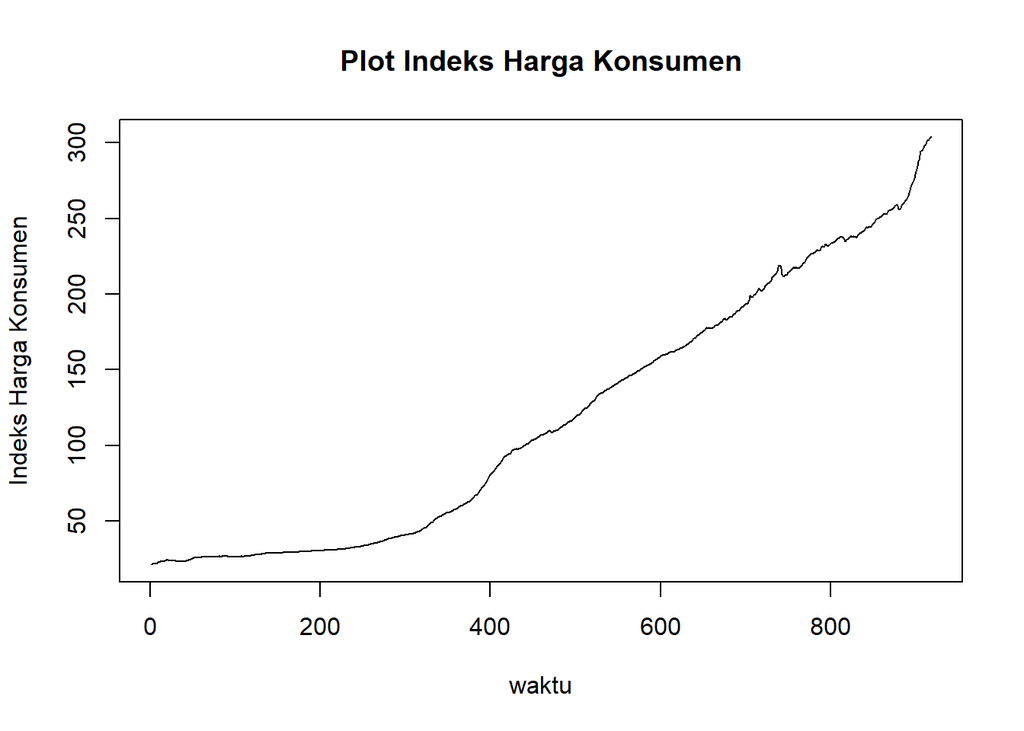

```r
plot.ts(Data67.ts, lty=1, xlab="waktu", ylab="Indeks Harga Konsumen", main="Plot Indeks Harga Konsumen")
```

Berdasarkan plot data deret waktu, terlihat bahwa data cenderung memiliki trend yang naik. Berdasarkan pola data, pembagian data latih dan data uji ditetapkan dengan proporsi 80%:20%.

## Data Latih

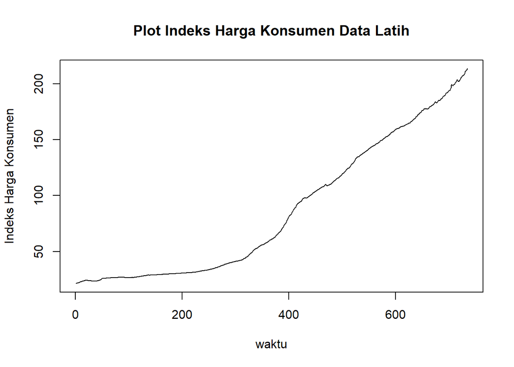

```r
Data67.train<-Data67[1:735]
train.ts<-ts(Data67.train)
plot.ts(train.ts, lty=1, xlab="waktu", ylab="Indeks Harga Konsumen", main="Plot Indeks Harga Konsumen Data Latih")
```

Berdasarkan plot data latih, terlihat bahwa data cenderung memiliki trend yang naik dan tidak stasioner.

## Data Uji

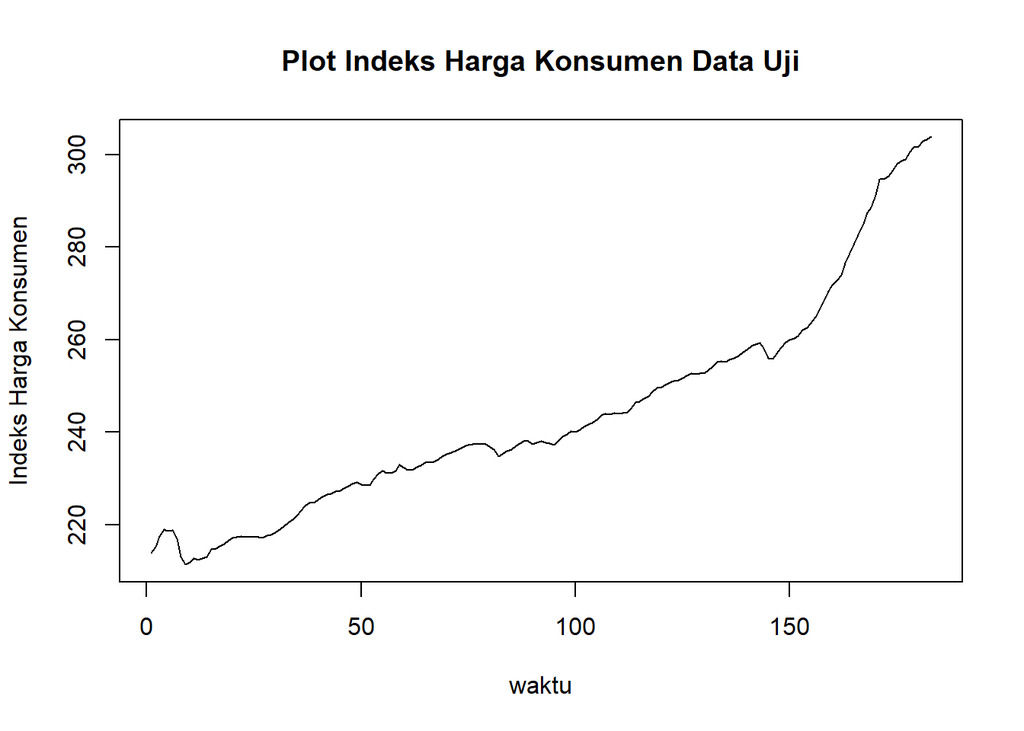

```r
Data67.test<-Data67[736:918]
test.ts<-ts(Data67.test)
plot.ts(test.ts, lty=1, xlab="waktu", ylab="Indeks Harga Konsumen", main="Plot Indeks Harga Konsumen Data Uji")
```

Plot dari data uji juga menunjukkan bahwa data memiliki pola tren naik dan tidak stasioner.

## Uji Kestasioneran Data

### Plot ACF

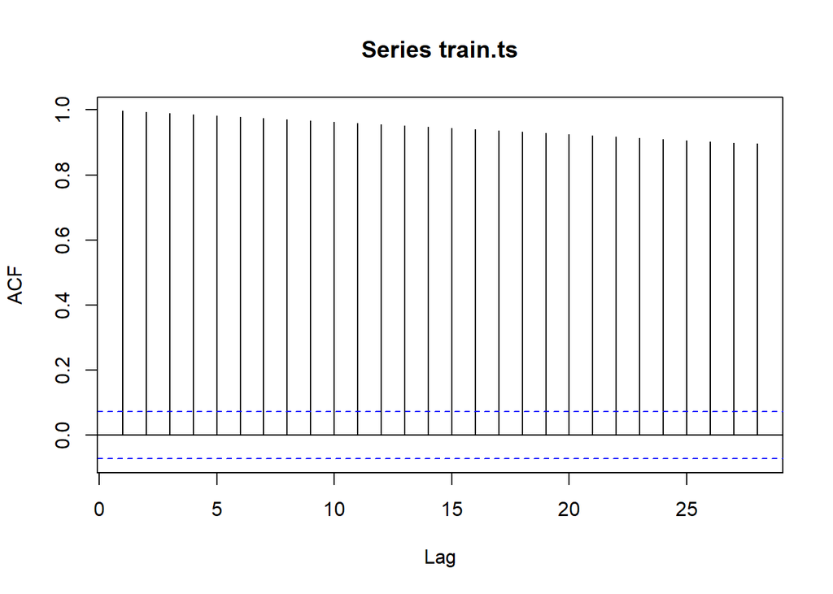

```r
acf(train.ts)
```

Berdasarkan plot ACF, terlihat bahwa data menurun secara perlahan (*tails of slowly*). Hal ini menjadi indikasi bahwa data tidak stasioner dalam rataan.

### Uji ADF

```r
tseries::adf.test(train.ts)
```

```
##
##  Augmented Dickey-Fuller Test
##
## data:  train.ts
## Dickey-Fuller = -1.4847, Lag order = 9, p-value = 0.7964
## alternative hypothesis: stationary
```

Berdasarkan uji ADF tersebut, didapat *p-value* sebesar 0.7964 yang lebih besar dari taraf nyata 5% sehingga menandakan bahwa data tidak stasioner dalam rataan. Hal ini sesuai dengan hasil eksplorasi menggunakan plot time series dan plot ACF, sehingga ketidakstasioneran model dalam rataan kedepannya harus ditangani.

### Plot Box-Cox

```r
index <- seq(1:length(train.ts))
bc = boxcox(train.ts~index, lambda = seq(-1,1,by=0.01))
```

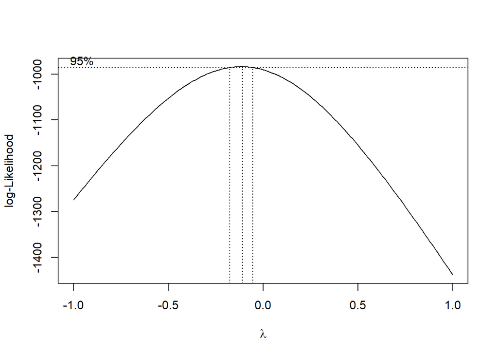

```r
lambda <- bc$x[which.max(bc$y)]
lambda
```

```
## [1] -0.11
```

```r
bc$x[bc$y > max(bc$y) - 1/2 * qchisq(.95,1)]
```

```
##  [1] -0.17 -0.16 -0.15 -0.14 -0.13 -0.12 -0.11 -0.10 -0.09 -0.08 -0.07 -0.06
```

Plot Boxcox menunjukkan nilai *rounded value* ($\lambda$) optimum sebesar **-0,11** dan pada selang kepercayaan 95% nilai memiliki batas bawah **-0,17** dan batas atas **-0,06**. Selang tersebut tidak memuat nilai satu sehingga dapat dikatakan bahwa data bangkitan tidak stasioner dalam ragam.

## Penanganan Ketidakstasioneran

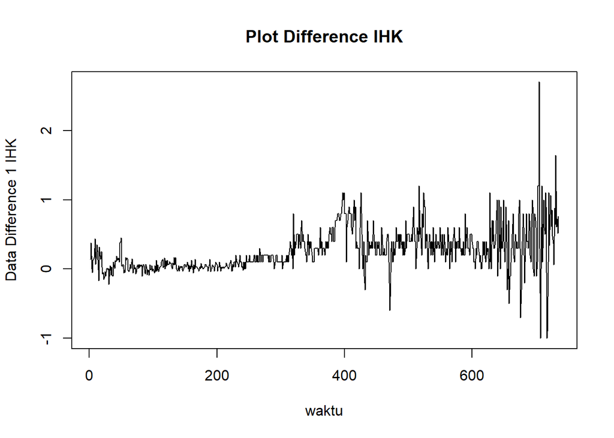

```r
train.diff<-diff(train.ts,differences = 1)
plot.ts(train.diff, lty=1, xlab="waktu", ylab="Data Difference 1 IHK", main="Plot Difference IHK")
```

Berdasarkan plot data deret waktu, terlihat bahwa data sudah stasioner dalam rataan ditandai dengan data bergerak pada nilai tengah tertentu (tidak terdapat trend ataupun musiman pada data).

### Plot ACF

```r
acf(train.diff)
```

[output not shown]

### Uji ADF

```r
tseries::adf.test(train.diff)
```

```
##
##  Augmented Dickey-Fuller Test
##
## data:  train.diff
## Dickey-Fuller = -3.5647, Lag order = 9, p-value = 0.03608
## alternative hypothesis: stationary
```

Berdasarkan uji ADF tersebut, didapat *p-value* sebesar 0.03608 yang lebih kecil dari taraf nyata 5% sehingga menandakan bahwa data sudah stasioner dalam rataan.

## Identifikasi Model

### Plot ACF

```r
acf(train.diff)
```

[output not shown]

### Plot PACF

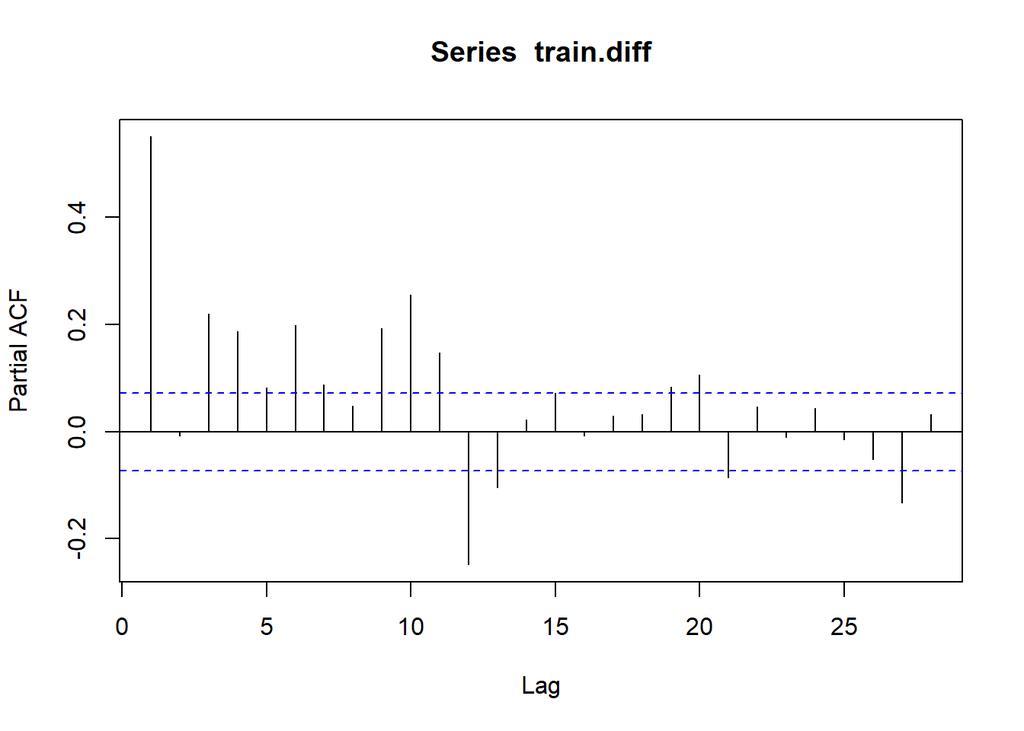

```r
pacf(train.diff)
```

### Plot EACF

```r
eacf(train.diff)
```

```
## AR/MA
##   0 1 2 3 4 5 6 7 8 9 10 11 12 13
## 0 x x x x x x x x x x x  x  x  x
## 1 o x o x o o o x o x x  x  x  o
## 2 o x x o o o o x o o x  x  x  x
## 3 x x x o o o o o o o x  x  o  x
## 4 x x x o x o o o o o x  x  x  o
## 5 x x x o x o o o o o x  x  x  x
## 6 x o x x x x o o o o x  x  x  x
## 7 x o x o x x o o o o x  x  o  x
```

Identifikasi model menggunakan plot EACF dilakukan dengan melihat ujung segitiga pada pola segitiga nol. Dalam hal ini model tentatif yang terbentuk adalah ARIMA(2,1,3) dan ARIMA(1,1,4)

## Pendugaan Parameter Model Tentatif

### ARIMA(2,1,0)

```r
model1=Arima(train.diff, order=c(2,1,0),method="ML")
summary(model1)
```

```
## Series: train.diff
## ARIMA(2,1,0)
##
## Coefficients:
##           ar1      ar2
##       -0.2970  -0.3673
## s.e.   0.0344   0.0344
##
## sigma^2 = 0.07086:  log likelihood = -69.12
## AIC=144.25   AICc=144.28   BIC=158.04
##
## Training set error measures:
##                       ME      RMSE       MAE MPE MAPE     MASE       ACF1
## Training set 0.001266898 0.2656573 0.1561506 NaN  Inf 0.917539 -0.1012788
```

```r
lmtest::coeftest(model1)
```

```
##
## z test of coefficients:
##
##      Estimate Std. Error  z value  Pr(>|z|)
## ar1 -0.297008   0.034365  -8.6428 < 2.2e-16 ***
## ar2 -0.367261   0.034374 -10.6843 < 2.2e-16 ***
## ---
## Signif. codes:  0 '***' 0.001 '**' 0.01 '*' 0.05 '.' 0.1 ' ' 1
```

Berdasarkan model pertama, didapatkan nilai *AIC* sebesar **144,25** dan semua parameter signifikan.

### ARIMA(2,1,3)

```r
model2=Arima(train.diff, order=c(2,1,3),method="ML")
summary(model2)
```

```
## Series: train.diff
## ARIMA(2,1,3)
##
## Coefficients:
##           ar1      ar2      ma1      ma2      ma3
##       -0.4196  -0.3720  -0.1500  -0.2773  -0.3851
## s.e.   0.2513   0.0894   0.2572   0.1756   0.1013
##
## sigma^2 = 0.05622:  log likelihood = 16.56
## AIC=-21.11   AICc=-21   BIC=6.47
##
## Training set error measures:
##                       ME      RMSE       MAE MPE MAPE      MASE         ACF1
## Training set 0.006349912 0.2361422 0.1440516 NaN  Inf 0.8464453 -0.007371486
```

```r
lmtest::coeftest(model2)
```

```
##
## z test of coefficients:
##
##      Estimate Std. Error z value  Pr(>|z|)
## ar1 -0.419629   0.251297 -1.6699 0.0949481 .
## ar2 -0.372023   0.089414 -4.1607 3.173e-05 ***
## ma1 -0.150030   0.257224 -0.5833 0.5597140
## ma2 -0.277285   0.175570 -1.5793 0.1142592
## ma3 -0.385107   0.101308 -3.8013 0.0001439 ***
## ---
## Signif. codes:  0 '***' 0.001 '**' 0.01 '*' 0.05 '.' 0.1 ' ' 1
```

Berdasarkan model kedua didapatkan nilai *AIC* sebesar **-21,11** dan hanya 2 parameter yang signifikan.

### ARIMA(1,1,4)

```r
model3=Arima(train.diff, order=c(1,1,4),method="ML")
summary(model3)
```

```
## Series: train.diff
## ARIMA(1,1,4)
##
## Coefficients:
##           ar1      ma1      ma2      ma3     ma4
##       -0.0590  -0.5241  -0.4702  -0.0530  0.1916
## s.e.   0.3508   0.3488   0.2051   0.1393  0.0439
##
## sigma^2 = 0.05581:  log likelihood = 19.3
## AIC=-26.59   AICc=-26.48   BIC=0.99
##
## Training set error measures:
##                       ME      RMSE      MAE MPE MAPE      MASE          ACF1
## Training set 0.005475183 0.2352645 0.143357 NaN  Inf 0.8423641 -0.0008112823
```

```r
lmtest::coeftest(model3)
```

```
##
## z test of coefficients:
##
##      Estimate Std. Error z value  Pr(>|z|)
## ar1 -0.058963   0.350783 -0.1681   0.86651
## ma1 -0.524051   0.348795 -1.5025   0.13298
## ma2 -0.470237   0.205072 -2.2930   0.02185 *
## ma3 -0.053032   0.139289 -0.3807   0.70340
## ma4  0.191616   0.043939  4.3610 1.295e-05 ***
## ---
## Signif. codes:  0 '***' 0.001 '**' 0.01 '*' 0.05 '.' 0.1 ' ' 1
```

Berdasarkan model kedua didapatkan nilai *AIC* sebesar **-26,59** dan hanya 2 parameter yang signifikan.

Karena pada model kedua dan ketiga hanya terdapat 2 parameter yang signifikan, sehingga model yang dipilih yaitu model pertama ARIMA(2,1,0).

## Eksplorasi Sisaan

### Eksplorasi Sisaan

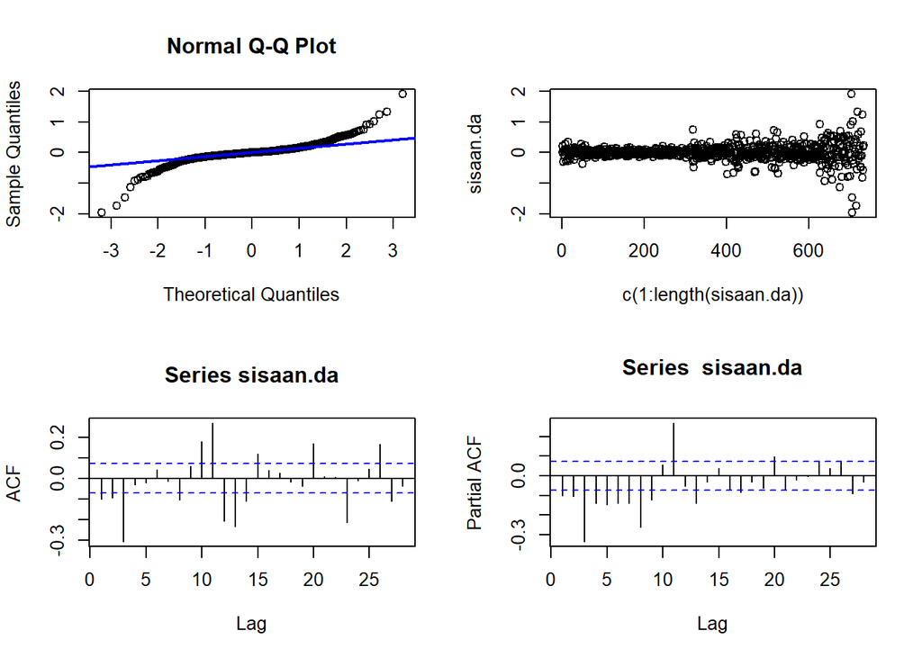

```r
#Eksplorasi
sisaan.da <- model1$residuals
par(mfrow=c(2,2))
qqnorm(sisaan.da)
qqline(sisaan.da, col = "blue", lwd = 2)
plot(c(1:length(sisaan.da)),sisaan.da)
acf(sisaan.da)
pacf(sisaan.da)
```

```r
par(mfrow = c(1,1))
```

Berdasarkan plot kuantil-kuantil normal, secara eksplorasi ditunjukkan sisaan tidak menyebar normal ditandai dengan titik titik yang cenderung tidak mengikuti garis. Kemudian dapat dilihat juga lebar pita sisaan yang cenderung tidak sama menandakan bahwa sisaan memiliki ragam yang heterogen. Selain itu dapat dilihat juga bahwa sisaan tidak saling bebas.

### Uji Formal

```r
# Sisaan Menyebar Normal
ks.test(sisaan.da,"pnorm")
```

```
##
##  Asymptotic one-sample Kolmogorov-Smirnov test
##
## data:  sisaan.da
## D = 0.32428, p-value < 2.2e-16
## alternative hypothesis: two-sided
```

Berdasarkan uji KS tersebut, didapat *p-value* sebesar 2.2e-16 yang kurang dari taraf nyata 5% sehingga tolak $H_0$ dan menandakan bahwa sisaan tidak menyebar normal. Hal ini sesuai dengan hasil eksplorasi menggunakan plot kuantil-kuantil normal.

```r
# Sisaan Saling Bebas
Box.test(sisaan.da, type = "Ljung")
```

```
##
##  Box-Ljung test
##
## data:  sisaan.da
## X-squared = 7.5597, df = 1, p-value = 0.005969
```

Berdasarkan uji Ljung-Box tersebut, didapat *p-value* sebesar 0.005969 yang lebih kecil dari taraf nyata 5% sehingga tolak $H_0$ dan menandakan bahwa sisaan tidak saling bebas.

```r
# Sisaan Homogen
Box.test((sisaan.da)^2, type = "Ljung")
```

```
##
##  Box-Ljung test
##
## data:  (sisaan.da)^2
## X-squared = 145.73, df = 1, p-value < 2.2e-16
```

Berdasarkan uji Ljung-Box terhadap sisaan kuadrat tersebut, didapat *p-value* sebesar 2.2e-16 yang kurang dari taraf nyata 5% sehingga tolak $H_0$ dan menandakan bahwa ragam sisaan tidak homogen.

```r
# Nilai tengah sisaan sama dengan nol
t.test(sisaan.da, mu = 0, conf.level = 0.95)
```

```
##
##  One Sample t-test
##
## data:  sisaan.da
## t = 0.12912, df = 733, p-value = 0.8973
## alternative hypothesis: true mean is not equal to 0
## 95 percent confidence interval:
##  -0.0179964  0.0205302
## sample estimates:
##   mean of x
## 0.001266898
```

Berdasarkan uji-ttersebut, didapat *p-value* sebesar 0.8973 yang lebih besar dari taraf nyata 5% sehingga tak tolak $H_0$ dan menandakan bahwa nilai tengah sisaan sama dengan nol.

## Overfitting

### ARIMA(3,1,0)

```r
model4=Arima(train.diff, order=c(3,1,0),method="ML")
summary(model4)
```

```
## Series: train.diff
## ARIMA(3,1,0)
##
## Coefficients:
##           ar1      ar2      ar3
##       -0.3980  -0.4485  -0.2742
## s.e.   0.0355   0.0347   0.0355
##
## sigma^2 = 0.0656:  log likelihood = -40.48
## AIC=88.96   AICc=89.02   BIC=107.35
##
## Training set error measures:
##                       ME      RMSE       MAE MPE MAPE      MASE        ACF1
## Training set 0.001560274 0.2554358 0.1536379 NaN  Inf 0.9027746 -0.04324545
```

```r
lmtest::coeftest(model4)
```

```
##
## z test of coefficients:
##
##      Estimate Std. Error  z value  Pr(>|z|)
## ar1 -0.398009   0.035534 -11.2009 < 2.2e-16 ***
## ar2 -0.448454   0.034680 -12.9313 < 2.2e-16 ***
## ar3 -0.274238   0.035523  -7.7201 1.162e-14 ***
## ---
## Signif. codes:  0 '***' 0.001 '**' 0.01 '*' 0.05 '.' 0.1 ' ' 1
```

Berdasarkan model pertama, didapatkan nilai *AIC* sebesar **88,96** dan semua parameter signifikan.

### ARIMA(2,1,1)

```r
model5=Arima(train.diff, order=c(2,1,1),method="ML")
summary(model5)
```

```
## Series: train.diff
## ARIMA(2,1,1)
##
## Coefficients:
##          ar1      ar2      ma1
##       0.3099  -0.2460  -0.8902
## s.e.  0.0396   0.0385   0.0216
##
## sigma^2 = 0.05618:  log likelihood = 15.82
## AIC=-23.64   AICc=-23.58   BIC=-5.25
##
## Training set error measures:
##                       ME      RMSE       MAE MPE MAPE      MASE        ACF1
## Training set 0.006005633 0.2363862 0.1437375 NaN  Inf 0.8445997 -0.00617498
```

```r
lmtest::coeftest(model5)
```

```
##
## z test of coefficients:
##
##      Estimate Std. Error  z value  Pr(>|z|)
## ar1  0.309895   0.039619   7.8218 5.206e-15 ***
## ar2 -0.245961   0.038463  -6.3947 1.609e-10 ***
## ma1 -0.890165   0.021626 -41.1617 < 2.2e-16 ***
## ---
## Signif. codes:  0 '***' 0.001 '**' 0.01 '*' 0.05 '.' 0.1 ' ' 1
```

Berdasarkan model pertama, didapatkan nilai *AIC* sebesar **-23,64** dan semua parameter signifikan.

Karena pada model overfitting ARIMA(2,1,1) memiliki *AIC* sebesar **-23,64** lebih kecil dari ARIMA(2,1,0) dan semua parameter signifikan. Maka model yang dipilih adalah ARIMA(2,1,1).

## Peramalan

```r
ramalan.da <- forecast::forecast(model5, h = length(test.ts))
ramalan.da
```

```
##     Point Forecast      Lo 80     Hi 80         Lo 95    Hi 95
## 736      0.7245602 0.42079018 1.0283301  0.2599840694 1.189136
## 737      0.6522694 0.32282612 0.9817126  0.1484294021 1.156109
## 738      0.6388296 0.30938118 0.9682779  0.1349817406 1.142677
## 739      0.6524453 0.32299380 0.9818968  0.1485927138 1.156298
## 740      0.6599704 0.32874220 0.9911987  0.1534005698 1.166540
## 741      0.6589535 0.32486420 0.9930428  0.1480080128 1.169899
## 742      0.6567875 0.32049193 0.9930830  0.1424678196 1.171107
## 743      0.6563664 0.31830052 0.9944322  0.1393392824 1.173393
## 744      0.6567686 0.31693548 0.9966017  0.1370386900 1.176499
## 745      0.6569968 0.31530488 0.9986888  0.1344240879 1.179570
## 746      0.6569686 0.31339788 1.0005394  0.1315225119 1.182415
## 747      0.6569038 0.31148014 1.0023274  0.1286239226 1.185184
## 748      0.6568906 0.30963611 1.0041451  0.1258106945 1.187970
## 749      0.6569025 0.30782665 1.0059783  0.1230370831 1.190768
```

[output cut: 169 more lines]

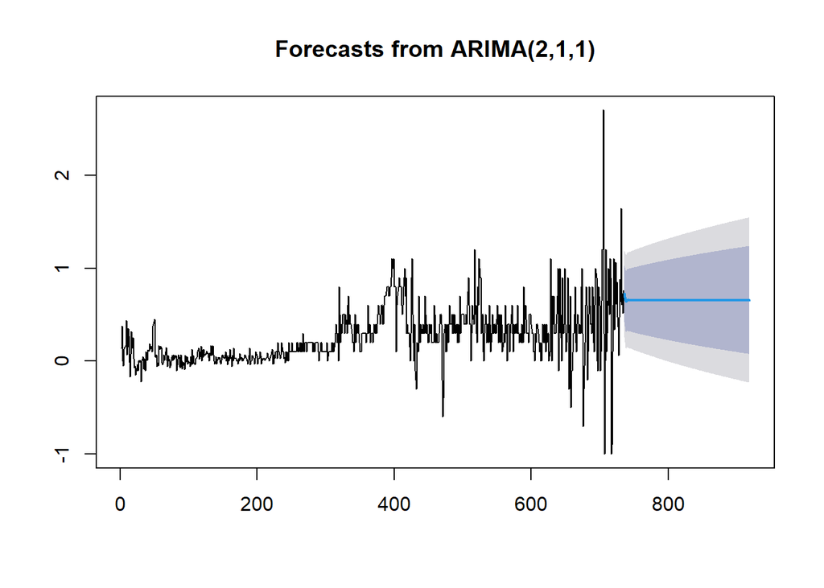

```r
data.ramalan.da <- ramalan.da$mean
plot(ramalan.da)
```

Berdasarkan hasil plot ramalan di atas, dapat dilihat bahwa ramalan ARIMA(2,1,1) cenderung stabil hingga akhir periode. Selanjutnya, dapat dicari nilai akurasi antara hasil ramalan dengan data uji.

## Akurasi

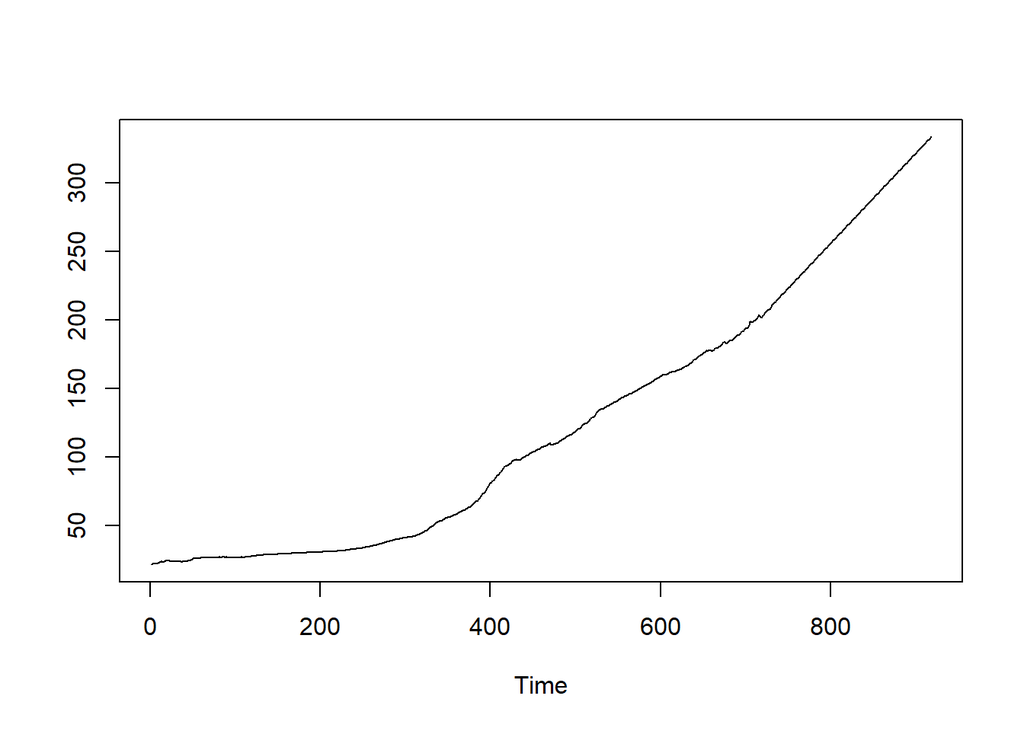

```r
pt_1 <- train.ts[735]
hasil.forc.Diff <- data.ramalan.da
hasil <- diffinv(hasil.forc.Diff, differences = 1) + pt_1
ts.plot(train.ts,hasil)
```

```r
perbandingan.da<-matrix(data=c(head(test.ts, n=183), hasil[-1]),
                     nrow = 183, ncol = 2)
colnames(perbandingan.da)<-c("Aktual","Hasil Forecast")
perbandingan.da
```

```
##         Aktual Hasil Forecast
##   [1,] 213.942       214.1726
##   [2,] 215.208       214.8248
##   [3,] 217.463       215.4637
##   [4,] 219.016       216.1161
##   [5,] 218.690       216.7761
##   [6,] 218.877       217.4350
##   [7,] 216.995       218.0918
##   [8,] 213.153       218.7482
##   [9,] 211.398       219.4050
##  [10,] 211.933       220.0619
##  [11,] 212.705       220.7189
##  [12,] 212.495       221.3758
##  [13,] 212.709       222.0327
##  [14,] 213.022       222.6896
```

[output cut: 169 more lines]

```r
accuracy(ts(hasil[-1]), head(test.ts, n=183))
```

```
##                 ME     RMSE      MAE       MPE     MAPE      ACF1 Theil's U
## Test set -29.90475 33.36402 29.99916 -11.96765 12.01088 0.9874302  34.76565
```

Peramalan memberikan nilai *MAPE* sebesar **12.01088** yang lebih besar dari 10. Maka dapat disimpulkan bahwa peramalan kurang baik.

# Praktikum Pertemuan 6&7

Uiwang Nur Thoriq

2023-10-16

## Package

```r
library(ggplot2)
library(tsibble)
library(tseries)
library(MASS)
library(forecast)
library(TSA)
library(TTR)
library(aTSA)
library(graphics)
library(rio)
```

## Input Data dan Time Series

```r
Data67<-import("https://raw.githubusercontent.com/UiwangNT/Praktikum_MPDW/main/data/US_inflation_rates_csv.csv")
Data67<-Data67[,3]
Data67.ts<-ts(Data67)
```

## Eksplorasi

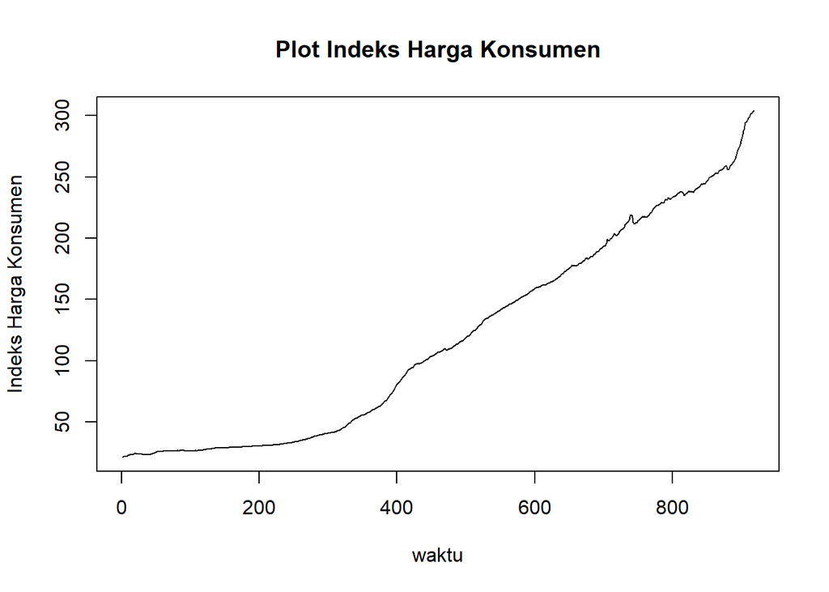

```r
plot.ts(Data67.ts, lty=1, xlab="waktu", ylab="Indeks Harga Konsumen", main="Plot Indeks Harga Konsumen")
```

Berdasarkan plot data deret waktu, terlihat bahwa data cenderung memiliki trend yang naik. Berdasarkan pola data, pembagian data latih dan data uji ditetapkan dengan proporsi 80%:20%.

## Data Latih

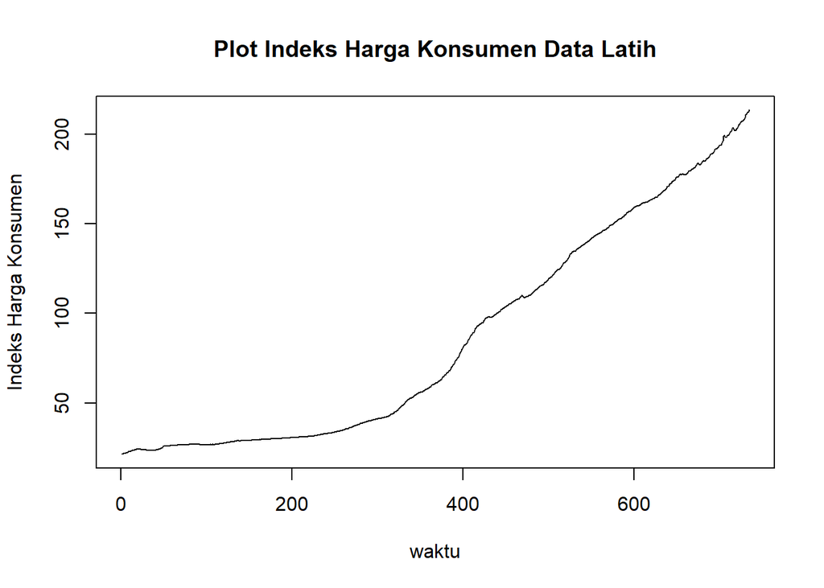

```r
Data67.train<-Data67[1:735]
train.ts<-ts(Data67.train)
plot.ts(train.ts, lty=1, xlab="waktu", ylab="Indeks Harga Konsumen", main="Plot Indeks Harga Konsumen Data Latih")
```

Berdasarkan plot data latih, terlihat bahwa data cenderung memiliki trend yang naik dan tidak stasioner.

## Data Uji

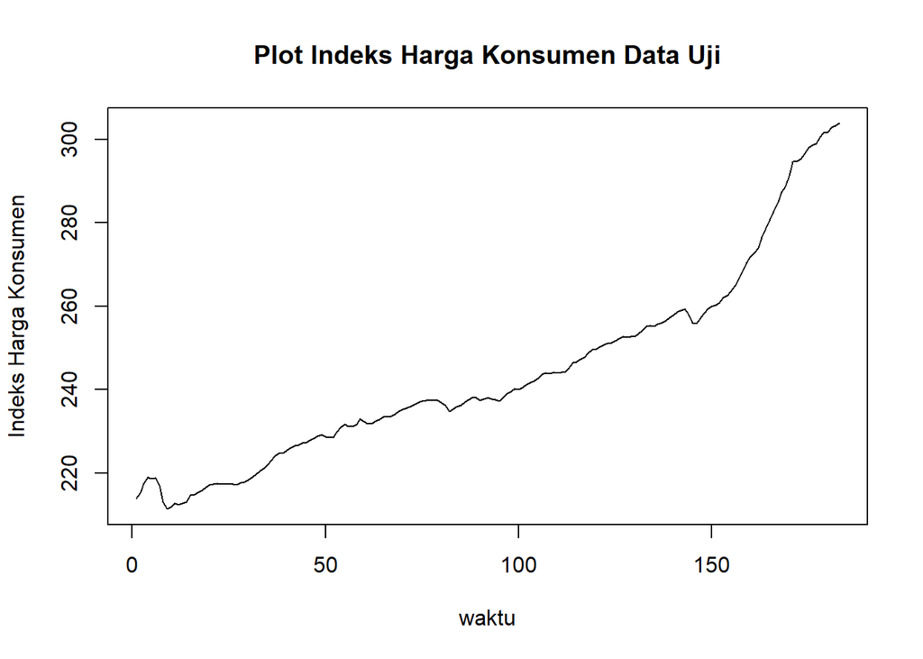

```r
Data67.test<-Data67[736:918]
test.ts<-ts(Data67.test)
plot.ts(test.ts, lty=1, xlab="waktu", ylab="Indeks Harga Konsumen", main="Plot Indeks Harga Konsumen Data Uji")
```

Plot dari data uji juga menunjukkan bahwa data memiliki pola tren naik dan tidak stasioner.

## Uji Kestasioneran Data

### Plot ACF

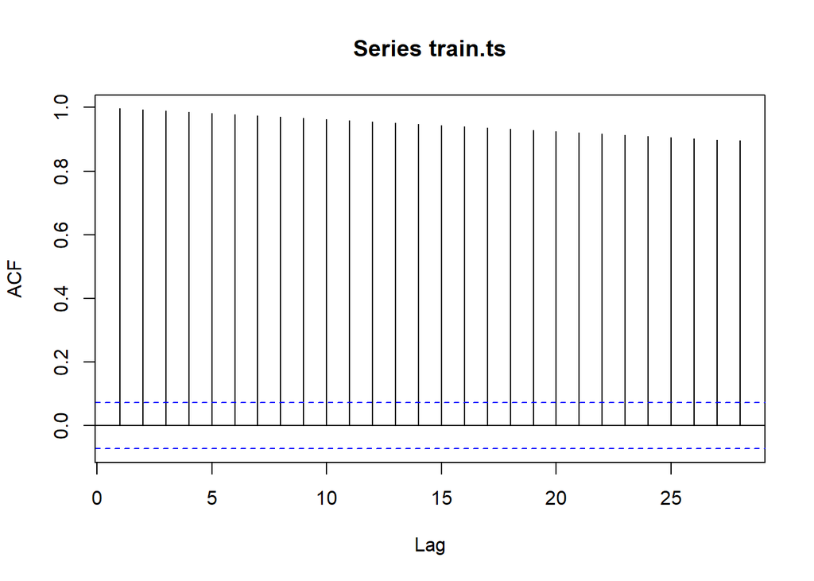

```r
acf(train.ts)
```

Berdasarkan plot ACF, terlihat bahwa data menurun secara perlahan (*tails of slowly*). Hal ini menjadi indikasi bahwa data tidak stasioner dalam rataan.

### Uji ADF

```r
tseries::adf.test(train.ts)
```

```
##
##  Augmented Dickey-Fuller Test
##
## data:  train.ts
## Dickey-Fuller = -1.4847, Lag order = 9, p-value = 0.7964
## alternative hypothesis: stationary
```

Berdasarkan uji ADF tersebut, didapat *p-value* sebesar 0.7964 yang lebih besar dari taraf nyata 5% sehingga menandakan bahwa data tidak stasioner dalam rataan. Hal ini sesuai dengan hasil eksplorasi menggunakan plot time series dan plot ACF, sehingga ketidakstasioneran model dalam rataan kedepannya harus ditangani.

### Plot Box-Cox

```r
index <- seq(1:length(train.ts))
bc = boxcox(train.ts~index, lambda = seq(-1,1,by=0.01))
```

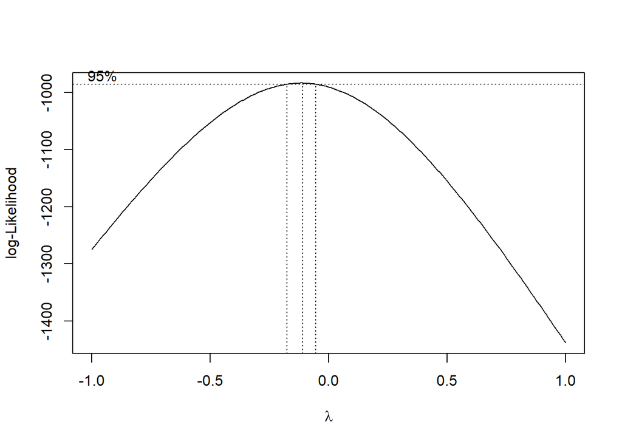

```r
lambda <- bc$x[which.max(bc$y)]
lambda
```

```
## [1] -0.11
```

```r
bc$x[bc$y > max(bc$y) - 1/2 * qchisq(.95,1)]
```

```
##  [1] -0.17 -0.16 -0.15 -0.14 -0.13 -0.12 -0.11 -0.10 -0.09 -0.08 -0.07 -0.06
```

Plot Boxcox menunjukkan nilai *rounded value* ($\lambda$) optimum sebesar **-0,11** dan pada selang kepercayaan 95% nilai memiliki batas bawah **-0,17** dan batas atas **-0,06**. Selang tersebut tidak memuat nilai satu sehingga dapat dikatakan bahwa data bangkitan tidak stasioner dalam ragam.

## Penanganan Ketidakstasioneran

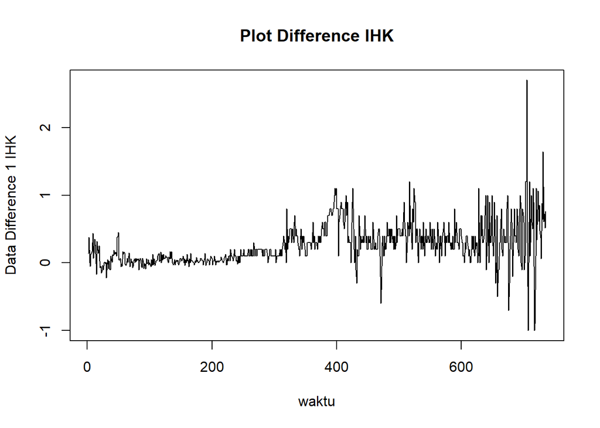

```r
train.diff<-diff(train.ts,differences = 1)
plot.ts(train.diff, lty=1, xlab="waktu", ylab="Data Difference 1 IHK", main="Plot Difference IHK")
```

Berdasarkan plot data deret waktu, terlihat bahwa data sudah stasioner dalam rataan ditandai dengan data bergerak pada nilai tengah tertentu (tidak terdapat trend ataupun musiman pada data).

### Plot ACF

```r
acf(train.diff)
```

[output not shown]

### Uji ADF

```r
tseries::adf.test(train.diff)
```

```
##
##  Augmented Dickey-Fuller Test
##
## data:  train.diff
## Dickey-Fuller = -3.5647, Lag order = 9, p-value = 0.03608
## alternative hypothesis: stationary
```

Berdasarkan uji ADF tersebut, didapat *p-value* sebesar 0.03608 yang lebih kecil dari taraf nyata 5% sehingga menandakan bahwa data sudah stasioner dalam rataan.

## Identifikasi Model

### Plot ACF

```r
acf(train.diff)
```

[output not shown]

### Plot PACF

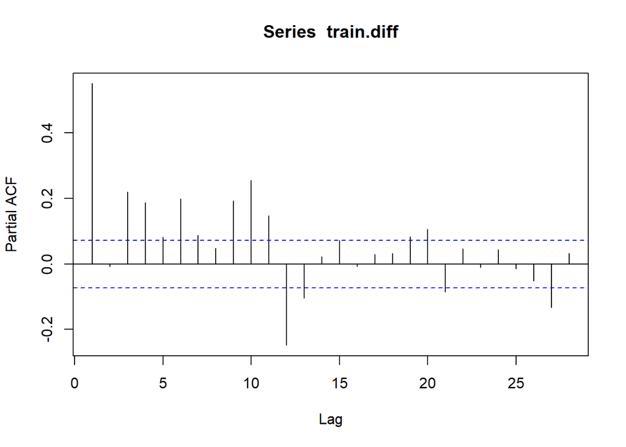

```r
pacf(train.diff)
```

### Plot EACF

```r
eacf(train.diff)
```

```
## AR/MA
##   0 1 2 3 4 5 6 7 8 9 10 11 12 13
## 0 x x x x x x x x x x x  x  x  x
## 1 o x o x o o o x o x x  x  x  o
## 2 o x x o o o o x o o x  x  x  x
## 3 x x x o o o o o o o x  x  o  x
## 4 x x x o x o o o o o x  x  x  o
## 5 x x x o x o o o o o x  x  x  x
## 6 x o x x x x o o o o x  x  x  x
## 7 x o x o x x o o o o x  x  o  x
```

Identifikasi model menggunakan plot EACF dilakukan dengan melihat ujung segitiga pada pola segitiga nol. Dalam hal ini model tentatif yang terbentuk adalah ARIMA(2,1,3) dan ARIMA(1,1,4)

## Pendugaan Parameter Model Tentatif

### ARIMA(2,1,0)

```r
model1=Arima(train.diff, order=c(2,1,0),method="ML")
summary(model1)
```

```
## Series: train.diff
## ARIMA(2,1,0)
##
## Coefficients:
##           ar1      ar2
##       -0.2970  -0.3673
## s.e.   0.0344   0.0344
##
## sigma^2 = 0.07086:  log likelihood = -69.12
## AIC=144.25   AICc=144.28   BIC=158.04
##
## Training set error measures:
##                       ME      RMSE       MAE MPE MAPE     MASE       ACF1
## Training set 0.001266898 0.2656573 0.1561506 NaN  Inf 0.917539 -0.1012788
```

```r
lmtest::coeftest(model1)
```

```
##
## z test of coefficients:
##
##      Estimate Std. Error  z value  Pr(>|z|)
## ar1 -0.297008   0.034365  -8.6428 < 2.2e-16 ***
## ar2 -0.367261   0.034374 -10.6843 < 2.2e-16 ***
## ---
## Signif. codes:  0 '***' 0.001 '**' 0.01 '*' 0.05 '.' 0.1 ' ' 1
```

Berdasarkan model pertama, didapatkan nilai *AIC* sebesar **144,25** dan semua parameter signifikan.

### ARIMA(2,1,3)

```r
model2=Arima(train.diff, order=c(2,1,3),method="ML")
summary(model2)
```

```
## Series: train.diff
## ARIMA(2,1,3)
##
## Coefficients:
##           ar1      ar2      ma1      ma2      ma3
##       -0.4196  -0.3720  -0.1500  -0.2773  -0.3851
## s.e.   0.2513   0.0894   0.2572   0.1756   0.1013
##
## sigma^2 = 0.05622:  log likelihood = 16.56
## AIC=-21.11   AICc=-21   BIC=6.47
##
## Training set error measures:
##                       ME      RMSE       MAE MPE MAPE      MASE         ACF1
## Training set 0.006349912 0.2361422 0.1440516 NaN  Inf 0.8464453 -0.007371486
```

```r
lmtest::coeftest(model2)
```

```
##
## z test of coefficients:
##
##      Estimate Std. Error z value  Pr(>|z|)
## ar1 -0.419629   0.251297 -1.6699 0.0949481 .
## ar2 -0.372023   0.089414 -4.1607 3.173e-05 ***
## ma1 -0.150030   0.257224 -0.5833 0.5597140
## ma2 -0.277285   0.175570 -1.5793 0.1142592
## ma3 -0.385107   0.101308 -3.8013 0.0001439 ***
## ---
## Signif. codes:  0 '***' 0.001 '**' 0.01 '*' 0.05 '.' 0.1 ' ' 1
```

Berdasarkan model kedua didapatkan nilai *AIC* sebesar **-21,11** dan hanya 2 parameter yang signifikan.

### ARIMA(1,1,4)

```r
model3=Arima(train.diff, order=c(1,1,4),method="ML")
summary(model3)
```

```
## Series: train.diff
## ARIMA(1,1,4)
##
## Coefficients:
##           ar1      ma1      ma2      ma3     ma4
##       -0.0590  -0.5241  -0.4702  -0.0530  0.1916
## s.e.   0.3508   0.3488   0.2051   0.1393  0.0439
##
## sigma^2 = 0.05581:  log likelihood = 19.3
## AIC=-26.59   AICc=-26.48   BIC=0.99
##
## Training set error measures:
##                       ME      RMSE      MAE MPE MAPE      MASE          ACF1
## Training set 0.005475183 0.2352645 0.143357 NaN  Inf 0.8423641 -0.0008112823
```

```r
lmtest::coeftest(model3)
```

```
##
## z test of coefficients:
##
##      Estimate Std. Error z value  Pr(>|z|)
## ar1 -0.058963   0.350783 -0.1681   0.86651
## ma1 -0.524051   0.348795 -1.5025   0.13298
## ma2 -0.470237   0.205072 -2.2930   0.02185 *
## ma3 -0.053032   0.139289 -0.3807   0.70340
## ma4  0.191616   0.043939  4.3610 1.295e-05 ***
## ---
## Signif. codes:  0 '***' 0.001 '**' 0.01 '*' 0.05 '.' 0.1 ' ' 1
```

Berdasarkan model kedua didapatkan nilai *AIC* sebesar **-26,59** dan hanya 2 parameter yang signifikan.

Karena pada model kedua dan ketiga hanya terdapat 2 parameter yang signifikan, sehingga model yang dipilih yaitu model pertama ARIMA(2,1,0).

## Eksplorasi Sisaan

### Eksplorasi Sisaan

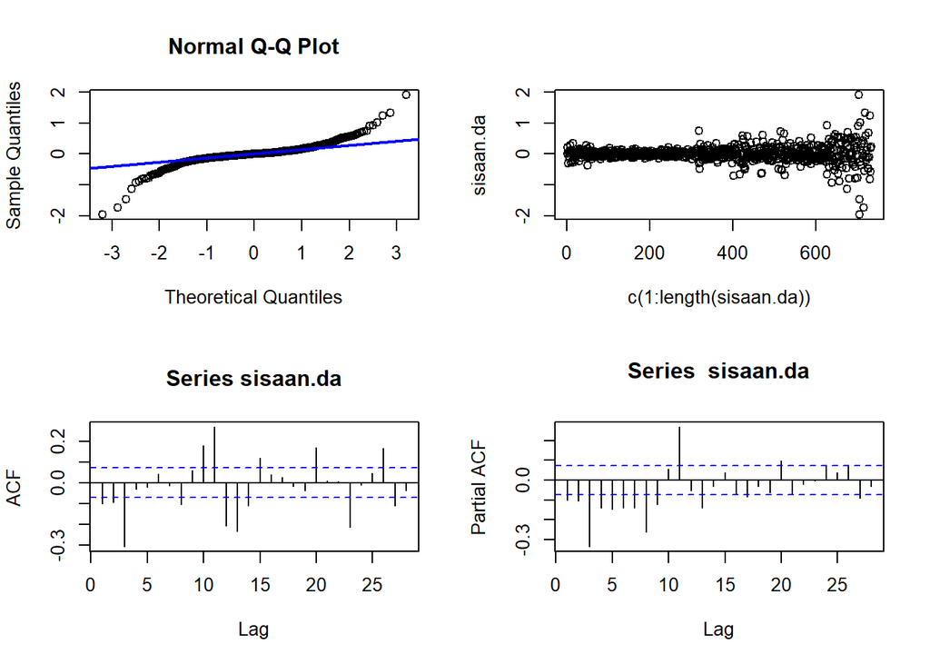

```r
#Eksplorasi
sisaan.da <- model1$residuals
par(mfrow=c(2,2))
qqnorm(sisaan.da)
qqline(sisaan.da, col = "blue", lwd = 2)
plot(c(1:length(sisaan.da)),sisaan.da)
acf(sisaan.da)
pacf(sisaan.da)
```

```r
par(mfrow = c(1,1))
```

Berdasarkan plot kuantil-kuantil normal, secara eksplorasi ditunjukkan sisaan tidak menyebar normal ditandai dengan titik titik yang cenderung tidak mengikuti garis. Kemudian dapat dilihat juga lebar pita sisaan yang cenderung tidak sama menandakan bahwa sisaan memiliki ragam yang heterogen. Selain itu dapat dilihat juga bahwa sisaan tidak saling bebas.

### Uji Formal

```r
# Sisaan Menyebar Normal
ks.test(sisaan.da,"pnorm")
```

```
##
##  Asymptotic one-sample Kolmogorov-Smirnov test
##
## data:  sisaan.da
## D = 0.32428, p-value < 2.2e-16
## alternative hypothesis: two-sided
```

Berdasarkan uji KS tersebut, didapat *p-value* sebesar 2.2e-16 yang kurang dari taraf nyata 5% sehingga tolak $H_0$ dan menandakan bahwa sisaan tidak menyebar normal. Hal ini sesuai dengan hasil eksplorasi menggunakan plot kuantil-kuantil normal.

```r
# Sisaan Saling Bebas
Box.test(sisaan.da, type = "Ljung")
```

```
##
##  Box-Ljung test
##
## data:  sisaan.da
## X-squared = 7.5597, df = 1, p-value = 0.005969
```

Berdasarkan uji Ljung-Box tersebut, didapat *p-value* sebesar 0.005969 yang lebih kecil dari taraf nyata 5% sehingga tolak $H_0$ dan menandakan bahwa sisaan tidak saling bebas.

```r
# Sisaan Homogen
Box.test((sisaan.da)^2, type = "Ljung")
```

```
##
##  Box-Ljung test
##
## data:  (sisaan.da)^2
## X-squared = 145.73, df = 1, p-value < 2.2e-16
```

Berdasarkan uji Ljung-Box terhadap sisaan kuadrat tersebut, didapat *p-value* sebesar 2.2e-16 yang kurang dari taraf nyata 5% sehingga tolak $H_0$ dan menandakan bahwa ragam sisaan tidak homogen.

```r
# Nilai tengah sisaan sama dengan nol
t.test(sisaan.da, mu = 0, conf.level = 0.95)
```

```
##
##  One Sample t-test
##
## data:  sisaan.da
## t = 0.12912, df = 733, p-value = 0.8973
## alternative hypothesis: true mean is not equal to 0
## 95 percent confidence interval:
##  -0.0179964  0.0205302
## sample estimates:
##   mean of x
## 0.001266898
```

Berdasarkan uji-ttersebut, didapat *p-value* sebesar 0.8973 yang lebih besar dari taraf nyata 5% sehingga tak tolak $H_0$ dan menandakan bahwa nilai tengah sisaan sama dengan nol.

## Overfitting

### ARIMA(3,1,0)

```r
model4=Arima(train.diff, order=c(3,1,0),method="ML")
summary(model4)
```

```
## Series: train.diff
## ARIMA(3,1,0)
##
## Coefficients:
##           ar1      ar2      ar3
##       -0.3980  -0.4485  -0.2742
## s.e.   0.0355   0.0347   0.0355
##
## sigma^2 = 0.0656:  log likelihood = -40.48
## AIC=88.96   AICc=89.02   BIC=107.35
##
## Training set error measures:
##                       ME      RMSE       MAE MPE MAPE      MASE        ACF1
## Training set 0.001560274 0.2554358 0.1536379 NaN  Inf 0.9027746 -0.04324545
```

```r
lmtest::coeftest(model4)
```

```
##
## z test of coefficients:
##
##      Estimate Std. Error  z value  Pr(>|z|)
## ar1 -0.398009   0.035534 -11.2009 < 2.2e-16 ***
## ar2 -0.448454   0.034680 -12.9313 < 2.2e-16 ***
## ar3 -0.274238   0.035523  -7.7201 1.162e-14 ***
## ---
## Signif. codes:  0 '***' 0.001 '**' 0.01 '*' 0.05 '.' 0.1 ' ' 1
```

Berdasarkan model pertama, didapatkan nilai *AIC* sebesar **88,96** dan semua parameter signifikan.

### ARIMA(2,1,1)

```r
model5=Arima(train.diff, order=c(2,1,1),method="ML")
summary(model5)
```

```
## Series: train.diff
## ARIMA(2,1,1)
##
## Coefficients:
##          ar1      ar2      ma1
##       0.3099  -0.2460  -0.8902
## s.e.  0.0396   0.0385   0.0216
##
## sigma^2 = 0.05618:  log likelihood = 15.82
## AIC=-23.64   AICc=-23.58   BIC=-5.25
##
## Training set error measures:
##                       ME      RMSE       MAE MPE MAPE      MASE        ACF1
## Training set 0.006005633 0.2363862 0.1437375 NaN  Inf 0.8445997 -0.00617498
```

```r
lmtest::coeftest(model5)
```

```
##
## z test of coefficients:
##
##      Estimate Std. Error  z value  Pr(>|z|)
## ar1  0.309895   0.039619   7.8218 5.206e-15 ***
## ar2 -0.245961   0.038463  -6.3947 1.609e-10 ***
## ma1 -0.890165   0.021626 -41.1617 < 2.2e-16 ***
## ---
## Signif. codes:  0 '***' 0.001 '**' 0.01 '*' 0.05 '.' 0.1 ' ' 1
```

Berdasarkan model pertama, didapatkan nilai *AIC* sebesar **-23,64** dan semua parameter signifikan.

Karena pada model overfitting ARIMA(2,1,1) memiliki *AIC* sebesar **-23,64** lebih kecil dari ARIMA(2,1,0) dan semua parameter signifikan. Maka model yang dipilih adalah ARIMA(2,1,1).

## Peramalan

```r
ramalan.da <- forecast::forecast(model5, h = length(test.ts))
ramalan.da
```

```
##     Point Forecast      Lo 80     Hi 80         Lo 95    Hi 95
## 736      0.7245602 0.42079018 1.0283301  0.2599840694 1.189136
## 737      0.6522694 0.32282612 0.9817126  0.1484294021 1.156109
## 738      0.6388296 0.30938118 0.9682779  0.1349817406 1.142677
## 739      0.6524453 0.32299380 0.9818968  0.1485927138 1.156298
## 740      0.6599704 0.32874220 0.9911987  0.1534005698 1.166540
## 741      0.6589535 0.32486420 0.9930428  0.1480080128 1.169899
## 742      0.6567875 0.32049193 0.9930830  0.1424678196 1.171107
## 743      0.6563664 0.31830052 0.9944322  0.1393392824 1.173393
## 744      0.6567686 0.31693548 0.9966017  0.1370386900 1.176499
## 745      0.6569968 0.31530488 0.9986888  0.1344240879 1.179570
## 746      0.6569686 0.31339788 1.0005394  0.1315225119 1.182415
## 747      0.6569038 0.31148014 1.0023274  0.1286239226 1.185184
## 748      0.6568906 0.30963611 1.0041451  0.1258106945 1.187970
## 749      0.6569025 0.30782665 1.0059783  0.1230370831 1.190768
```

[output cut: 169 more lines]

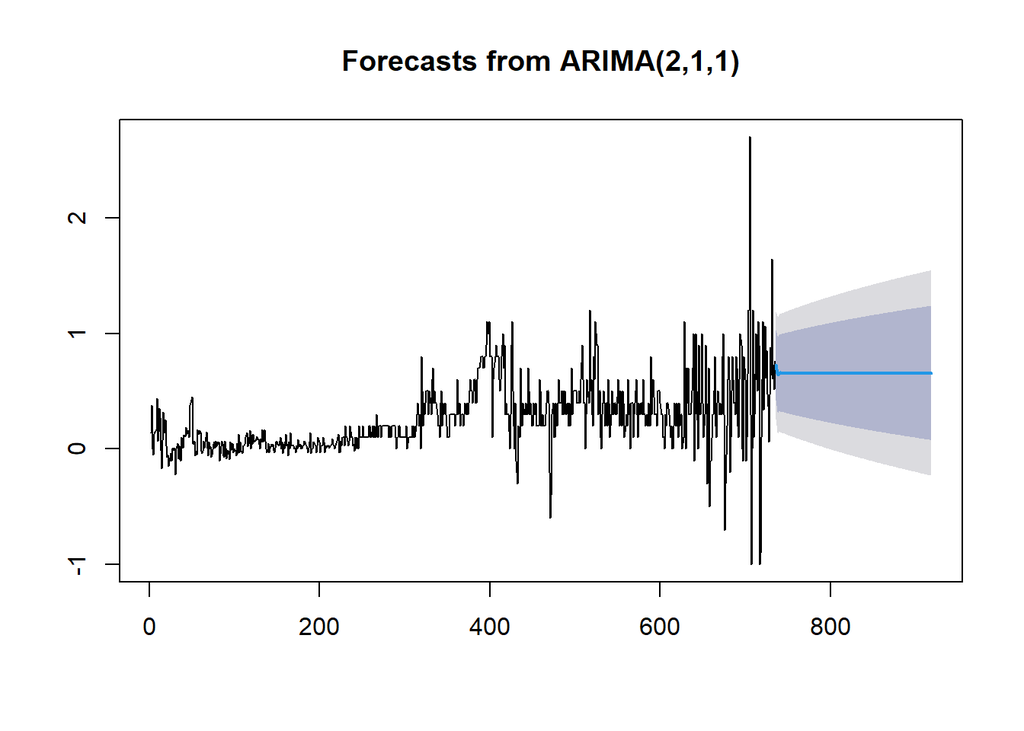

```r
data.ramalan.da <- ramalan.da$mean
plot(ramalan.da)
```

Berdasarkan hasil plot ramalan di atas, dapat dilihat bahwa ramalan ARIMA(2,1,1) cenderung stabil hingga akhir periode. Selanjutnya, dapat dicari nilai akurasi antara hasil ramalan dengan data uji.

## Akurasi

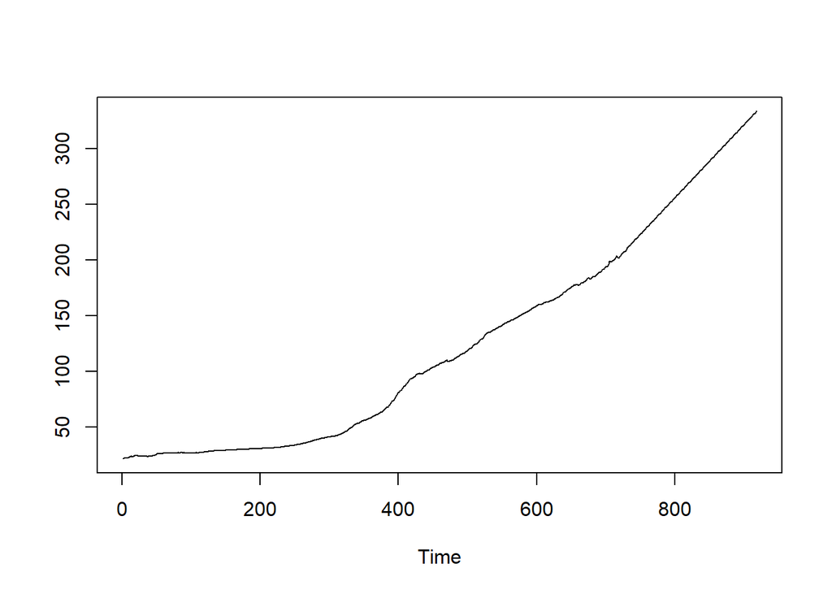

```r
pt_1 <- train.ts[735]
hasil.forc.Diff <- data.ramalan.da
hasil <- diffinv(hasil.forc.Diff, differences = 1) + pt_1
ts.plot(train.ts,hasil)
```

```r
perbandingan.da<-matrix(data=c(head(test.ts, n=183), hasil[-1]),
                     nrow = 183, ncol = 2)
colnames(perbandingan.da)<-c("Aktual","Hasil Forecast")
perbandingan.da
```

```
##         Aktual Hasil Forecast
##   [1,] 213.942       214.1726
##   [2,] 215.208       214.8248
##   [3,] 217.463       215.4637
##   [4,] 219.016       216.1161
##   [5,] 218.690       216.7761
##   [6,] 218.877       217.4350
##   [7,] 216.995       218.0918
##   [8,] 213.153       218.7482
##   [9,] 211.398       219.4050
##  [10,] 211.933       220.0619
##  [11,] 212.705       220.7189
##  [12,] 212.495       221.3758
##  [13,] 212.709       222.0327
##  [14,] 213.022       222.6896
```

[output cut: 169 more lines]

```r
accuracy(ts(hasil[-1]), head(test.ts, n=183))
```

```
##                 ME     RMSE      MAE       MPE     MAPE      ACF1 Theil's U
## Test set -29.90475 33.36402 29.99916 -11.96765 12.01088 0.9874302  34.76565
```

Peramalan memberikan nilai *MAPE* sebesar **12.01088** yang lebih besar dari 10. Maka dapat disimpulkan bahwa peramalan kurang baik.